# Lab 2: Basic visualisation and statistics

## Smoothing the histogram

(`bw` is the bandwidth). We split the graphics window in two parts using `par`

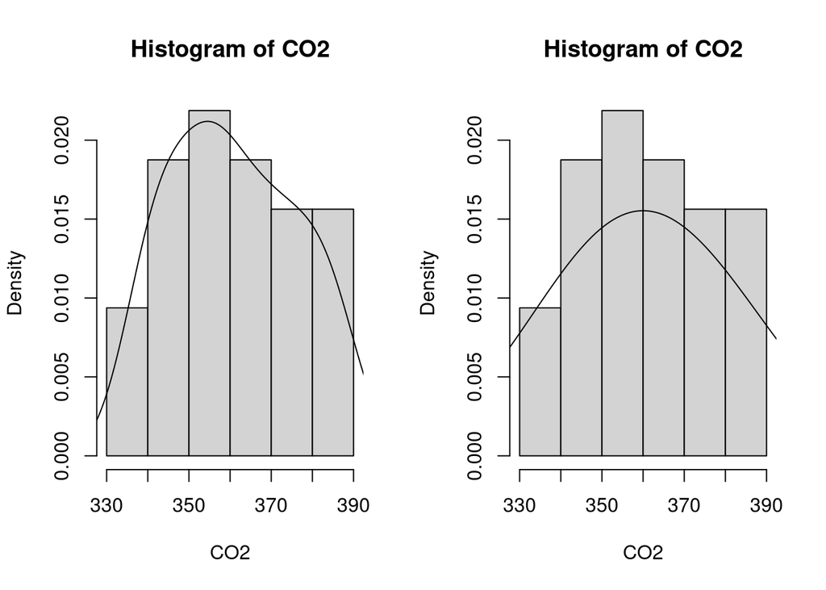

```r
par(mfrow=c(1,2))
hist(CO2,freq = FALSE)
lines(density(CO2))
hist(CO2,freq = FALSE)
lines(density(CO2,bw=20))
```

```r
par(mfrow=c(1,1))
```

## Empirical cumulative distribution function

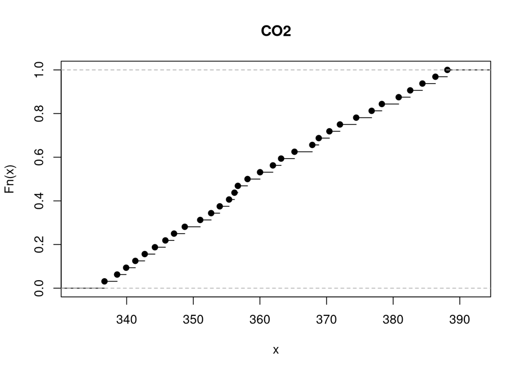

```r
plot(ecdf(CO2), main="CO2")
```

## Boxplot

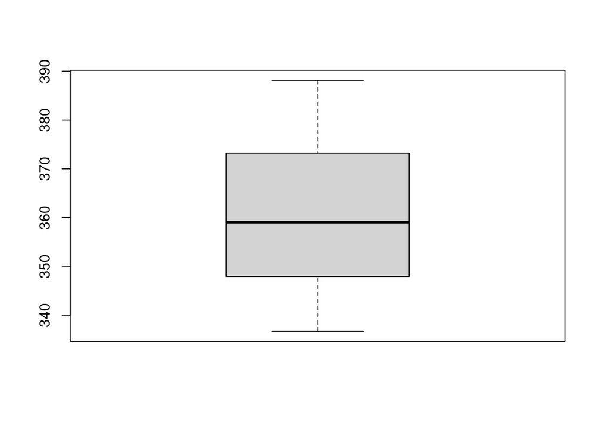

```r
boxplot(CO2)
```

# Some statistics for numerical variables

## Mean, median, quantiles

```r
mean(CO2)
```

```
## [1] 360.9488
```

```r
median(CO2)
```

```
## [1] 359.08
```

```r
quantile(CO2,prob=c(0.25,0.5,0.75))
```

```
##      25%      50%      75%
## 348.3175 359.0800 372.6200
```

## Standard deviation, variance, IQR

```r
sd(CO2)
```

```
## [1] 15.31573
```

```r
var(CO2)
```

```
## [1] 234.5717
```

```r
IQR(CO2)
```

```
## [1] 24.3025
```

## Skewness

```r
m<-mean(CO2)
mean((CO2-m)^3)/sd(CO2)^3
```

```
## [1] 0.1626514
```

## A first function in R

Writing your own functions can help with tasks that are carried out many times, which would otherwise result in a lot of code.

This code

```r
skewness<-function(x){
  m<-mean(x)
  s<-sd(x)
  sk<-mean((x-m)^3)/s^3
  return(sk)
}
skewness(CO2)
```

```
## [1] 0.1626514
```

defines a function named `skewness`. The function takes one ‘argument’ called `x` (i.e., input), which is a numeric vector and return the skewness index of `x`

# Working with the dataframe

```r
summary(Co2Dataset)
```

```
##       Year           Temp            CO2             TSI
##  Min.   :1979   Min.   : 4.00   Min.   :336.7   Min.   :1365
##  1st Qu.:1987   1st Qu.:19.00   1st Qu.:348.3   1st Qu.:1366
##  Median :1994   Median :32.00   Median :359.1   Median :1366
##  Mean   :1994   Mean   :33.59   Mean   :360.9   Mean   :1366
##  3rd Qu.:2002   3rd Qu.:49.75   3rd Qu.:372.6   3rd Qu.:1366
##  Max.   :2010   Max.   :63.00   Max.   :388.1   Max.   :1367
```

`apply` function takes dataframe or matrix as an input and gives output in vector, list or array. Function is primarily used to avoid explicit uses of loop constructs.

This function takes 3 arguments:

```r
apply(X, MARGIN, FUN)
```

Here:

- `X`: an array or matrix
- `MARGIN`: take a value or range between 1 and 2 to define where to apply the function:
  - `MARGIN=1`: the manipulation is performed on rows
  - `MARGIN=2`: the manipulation is performed on columns
  - `MARGIN=c(1,2)` the manipulation is performed on rows and columns
- `FUN`: tells which function to apply. Built functions like mean, median, sum, min, max and even user-defined functions can be applied

```r
apply(Co2Dataset,2,mean)
```

```
##       Year       Temp        CO2        TSI
## 1994.50000   33.59375  360.94875 1365.91031
```

# Working with categorical variables

Dataset *pupae.csv* is from an experiment where larvae of different gender (`Gender`, `Gender = 1` is a male) were left to feed on Eucalyptus leaves, in a glasshouse that was controlled at two different levels of temperature (`T_treatment`) and CO2 concentration (`CO2_treatment`). After the larvae pupated (that is, turned into pupae), the body weight was measured (`PupalWeight`), as well as the cumulative ’frass’ (`Frass`) (larvae excrement) over the entire time it took to pupate. It contains numerical and categorical variables

Read data

```r
pupae <- read.csv("pupae.csv")
head(pupae)
str(pupae)
```

```
##   T_treatment CO2_treatment Gender PupalWeight Frass
## 1     ambient           280      0       0.244 1.900
## 2     ambient           280      1       0.319 2.770
## 3     ambient           280      0       0.221    NA
## 4     ambient           280      0       0.280 1.996
## 5     ambient           280      0       0.257 1.069
## 6     ambient           280      1       0.333 2.257
```

```
## 'data.frame':    84 obs. of  5 variables:
##  $ T_treatment  : chr  "ambient" "ambient" "ambient" "ambient" ...
##  $ CO2_treatment: int  280 280 280 280 280 280 280 280 280 280 ...
##  $ Gender       : int  0 1 0 0 0 1 0 1 0 1 ...
##  $ PupalWeight  : num  0.244 0.319 0.221 0.28 0.257 0.333 0.275 0.312 0.254 0.356 ...
##  $ Frass        : num  1.9 2.77 NA 2 1.07 ...
```

Summary

```r
summary(pupae)
```

```
##  T_treatment        CO2_treatment       Gender        PupalWeight
##  Length:84          Min.   :280.0   Min.   :0.0000   Min.   :0.1720
##  Class :character   1st Qu.:280.0   1st Qu.:0.0000   1st Qu.:0.2562
##  Mode  :character   Median :400.0   Median :0.0000   Median :0.2975
##                     Mean   :344.3   Mean   :0.4487   Mean   :0.3110
##                     3rd Qu.:400.0   3rd Qu.:1.0000   3rd Qu.:0.3560
##                     Max.   :400.0   Max.   :1.0000   Max.   :0.4730
##                                     NA's   :6
##      Frass
##  Min.   :0.986
##  1st Qu.:1.515
##  Median :1.818
##  Mean   :1.846
##  3rd Qu.:2.095
##  Max.   :3.117
##  NA's   :1
```

We convert string variables into categorical (i.e. factor) variables

```r
pupae$T_treatment<-as.factor(pupae$T_treatment)
pupae$CO2_treatment<-as.factor(pupae$CO2_treatment)
pupae$Gender<-as.factor(pupae$Gender)
```

A new summary

```r
summary(pupae)
```

```
##    T_treatment CO2_treatment  Gender    PupalWeight         Frass
##  ambient :37   280:39        0   :43   Min.   :0.1720   Min.   :0.986
##  elevated:47   400:45        1   :35   1st Qu.:0.2562   1st Qu.:1.515
##                              NA's: 6   Median :0.2975   Median :1.818
##                                        Mean   :0.3110   Mean   :1.846
##                                        3rd Qu.:0.3560   3rd Qu.:2.095
##                                        Max.   :0.4730   Max.   :3.117
##                                                         NA's   :1
```

Another possibility is to convert directly the strings when you read the data

```r
pupae <- read.csv("pupae.csv",stringsAsFactors = TRUE)
is.factor(pupae$T_treatment)
```

```
## [1] TRUE
```

but `CO2_treatment` `pupae$Gender` are still numeric

```r
str(pupae)
```

```
## 'data.frame':    84 obs. of  5 variables:
##  $ T_treatment  : Factor w/ 2 levels "ambient","elevated": 1 1 1 1 1 1 1 1 1 1 ...
##  $ CO2_treatment: int  280 280 280 280 280 280 280 280 280 280 ...
##  $ Gender       : int  0 1 0 0 0 1 0 1 0 1 ...
##  $ PupalWeight  : num  0.244 0.319 0.221 0.28 0.257 0.333 0.275 0.312 0.254 0.356 ...
##  $ Frass        : num  1.9 2.77 NA 2 1.07 ...
```

so we need to convert them

```r
pupae$CO2_treatment<-as.factor(pupae$CO2_treatment)
pupae$Gender<-as.factor(pupae$Gender)
```

For factors, you can use the `table` function to generate a count of observations in each category

```r
table(pupae$CO2_treatment)
```

```
##
## 280 400
##  39  45
```

`tapply` computes a measure (mean, median, min, max, etc..) or a function for each factor variable in a vector. It is a very useful function that lets you create a subset of a vector and then apply some functions to each of the subset.

```r
tapply(X, INDEX, FUN = NULL)
```

Arguments:

- `X`: An object, usually a vector
- `INDEX`: A list containing factor
- `FUN`: Function applied to each element of x

Part of the job of researchers is to compute summaries of variables. For instance, measure the average or group data based on a characteristic. Most of the data are grouped by ID, city, countries, and so on. Summarizing over group reveals more interesting patterns.

```r
tapply(pupae$PupalWeight,pupae$CO2_treatment, mean)
```

```
##       280       400
## 0.2995641 0.3209556
```

# Missing data

We consider the built-in data set `airquality`

```r
summary(airquality)
```

```
##      Ozone           Solar.R           Wind             Temp
##  Min.   :  1.00   Min.   :  7.0   Min.   : 1.700   Min.   :56.00
##  1st Qu.: 18.00   1st Qu.:115.8   1st Qu.: 7.400   1st Qu.:72.00
##  Median : 31.50   Median :205.0   Median : 9.700   Median :79.00
##  Mean   : 42.13   Mean   :185.9   Mean   : 9.958   Mean   :77.88
##  3rd Qu.: 63.25   3rd Qu.:258.8   3rd Qu.:11.500   3rd Qu.:85.00
##  Max.   :168.00   Max.   :334.0   Max.   :20.700   Max.   :97.00
##  NA's   :37       NA's   :7
##      Month            Day
##  Min.   :5.000   Min.   : 1.0
##  1st Qu.:6.000   1st Qu.: 8.0
##  Median :7.000   Median :16.0
##  Mean   :6.993   Mean   :15.8
##  3rd Qu.:8.000   3rd Qu.:23.0
##  Max.   :9.000   Max.   :31.0
##
```

and note the presence of missing data. If some cases it may be suitable to simply drop all records with any missing values.

This is especially true with a large data set. In fact dropping a few observations may not have any effect on the results, so it might be easiest to simply drop any observation with missing data.

This this can be done easily using the `na.omit` function, as follows:

```r
airquality.new<-na.omit(airquality)
head(airquality)
```

```
##   Ozone Solar.R Wind Temp Month Day
## 1    41     190  7.4   67     5   1
## 2    36     118  8.0   72     5   2
## 3    12     149 12.6   74     5   3
## 4    18     313 11.5   62     5   4
## 5    NA      NA 14.3   56     5   5
## 6    28      NA 14.9   66     5   6
```

Some functions are smart enough to be able to handle missing data. For example, functions such as `max`, `mean`, `var`, `sd`, `sum` and others have an optional `na.rm` argument: `na.rm=TRUE` drops `NA` values before doing the calculation. Otherwise if x contains any NAs, `mean` and other similar functions will return an NA. For example, to calculate the mean

```r
mean(airquality$Ozone)
```

```
## [1] NA
```

```r
mean(airquality$Ozone,na.rm = TRUE)
```

```
## [1] 42.12931
```

In some cases it may be justifiable to replace the missing values with another value – although there should be a good reason for doing so!. In that case a strategy use the mean or median of across all other observations

```r
sel<-is.na(airquality$Ozone)
airquality.new<-airquality
airquality.new$Ozone[sel]<-mean(airquality$Ozone,na.rm = TRUE)
head(airquality.new)
```

```
##      Ozone Solar.R Wind Temp Month Day
## 1 41.00000     190  7.4   67     5   1
## 2 36.00000     118  8.0   72     5   2
## 3 12.00000     149 12.6   74     5   3
## 4 18.00000     313 11.5   62     5   4
## 5 42.12931      NA 14.3   56     5   5
## 6 28.00000      NA 14.9   66     5   6
```

# Data transformation

## Box-Cox transformation

Box-Cox transformation as function. Note that functions can have multiple arguments. By setting an argument, we set the default. In this case the default is the logarithm transform.

```r
boxcox<-function(x,lambda=0)
{
  if (lambda != 0.0)
  {
    val<-(x^lambda-1)/lambda
  } else {
    val<-log(x)
  }
  return(val)
}
```

Example. We use the variable `Ozone` of the built-in dataset `airquality`. and we split the graphic window in two subwindows.

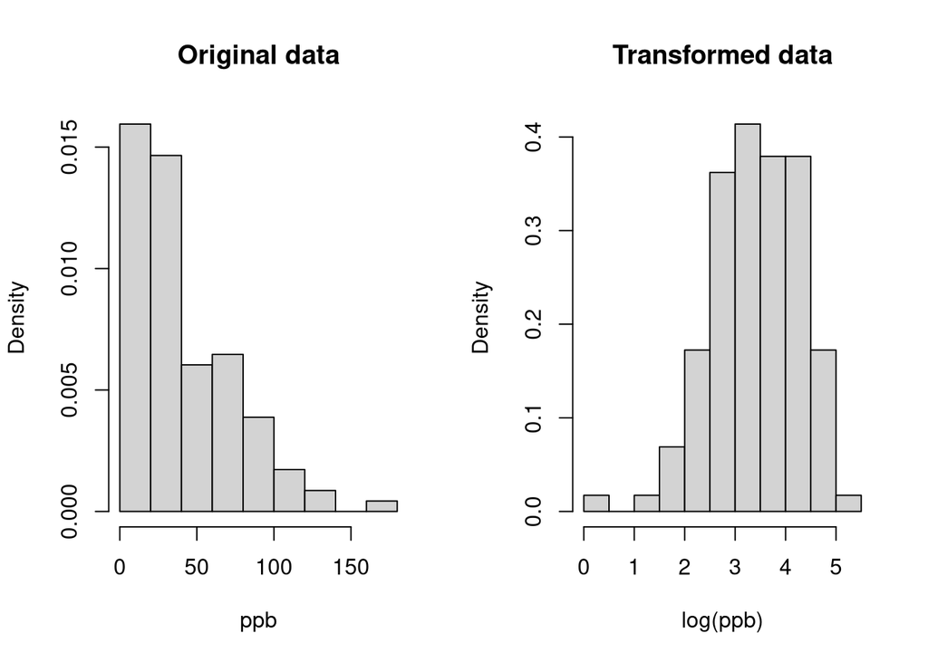

```r
par(mfrow=c(1,2))
hist(airquality$Ozone,freq=FALSE,xlab="ppb",main="Original data")
hist(boxcox(airquality$Ozone,0),freq=FALSE,xlab="log(ppb)",main="Transformed data")
```

```r
par(mfrow=c(1,1))
```

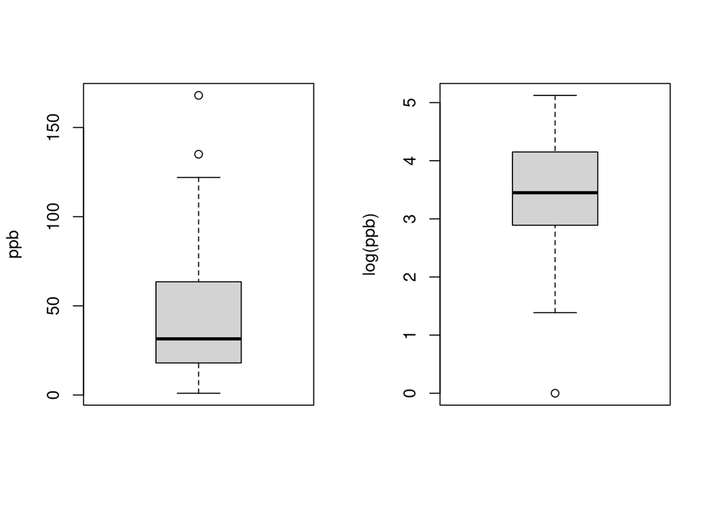

```r
par(mfrow=c(1,2))
boxplot(airquality$Ozone,ylab="ppb")
boxplot(boxcox(airquality$Ozone,0),ylab="log(ppb)")
```

```r
par(mfrow=c(1,1))
```

Function `boxcox` in the `MASS` package helps to identify the most likely value for $\lambda$

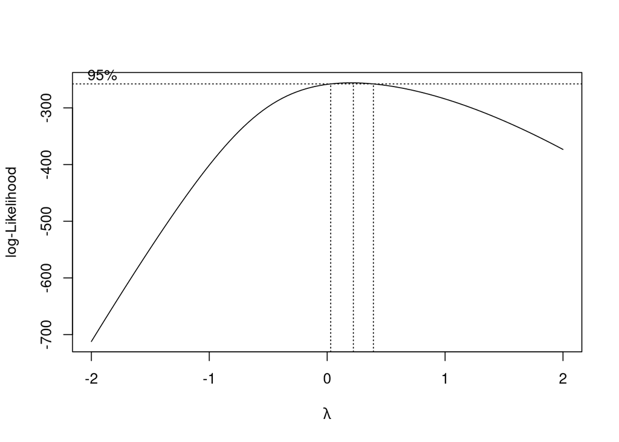

```r
MASS::boxcox(airquality$Ozone~1)
```

## Standardization

`scale` is the function that centers and/or scales the columns of a vector or a numeric matrix.

```r
y<-scale(CO2,center = TRUE, scale = FALSE)
mean(y)
```

```
## [1] -1.776357e-14
```

```r
sd(y)
```

```
## [1] 15.31573
```

```r
y<-scale(CO2,center = TRUE, scale = TRUE)
mean(y)
```

```
## [1] -1.16053e-15
```

```r
sd(y)
```

```
## [1] 1
```

# Relationships

## Between pairs of numerical variables: scatterplot, correlation

- Scatterplots are used to display two numeric variables

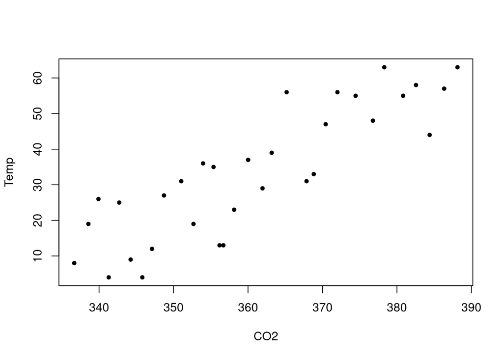

```r
plot(CO2,Temp,pch=20)
```

The next command gives the same figure. It is a formula-like command. The symbol `~` stands for against. In this example we also add a title

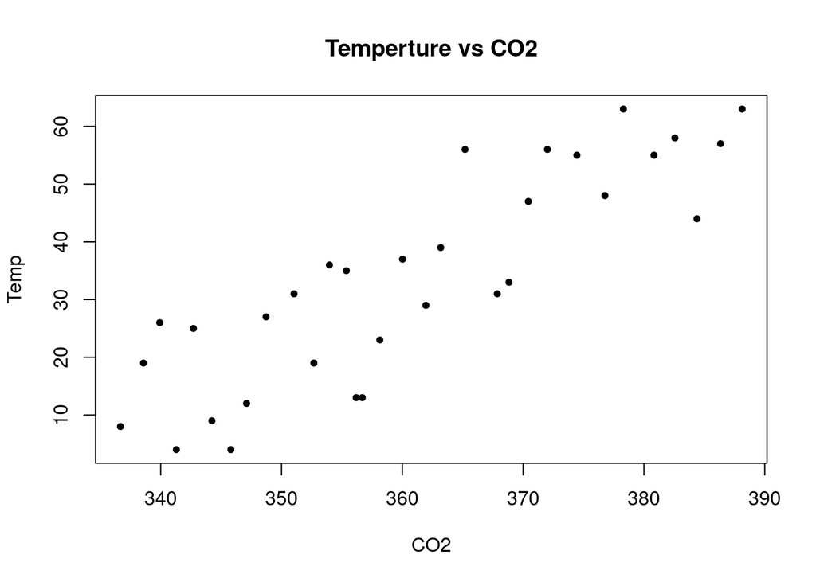

```r
plot(Temp~CO2,pch=20,main="Temperture vs CO2")
```

- correlation

```r
cor(CO2,Temp)
```

```
## [1] 0.8609274
```

- … or more

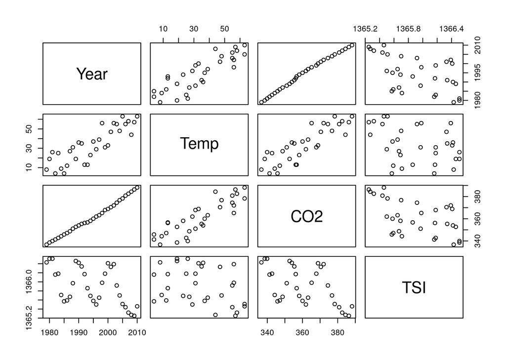

```r
pairs(Co2Dataset)
```

- Spearman correlation index

```r
cor(CO2,Temp,method="spearman")
```

```
## [1] 0.8612565
```

- $\tau$ correlation index

```r
cor(CO2,Temp,method="kendall")
```

```
## [1] 0.6842812
```

- If function `cor` is applied to an entire data frame, then the correlation matrix containing all pairwise correlation is returned.

```r
cor(Co2Dataset)
```

```
##            Year       Temp        CO2        TSI
## Year  1.0000000  0.8560901  0.9972488 -0.5358116
## Temp  0.8560901  1.0000000  0.8609274 -0.3403420
## CO2   0.9972488  0.8609274  1.0000000 -0.5428219
## TSI  -0.5358116 -0.3403420 -0.5428219  1.0000000
```

Consider the pre-built dataset `airquality`. It contains some missing values

```r
apply(is.na(airquality),2,sum)
```

```
##   Ozone Solar.R    Wind    Temp   Month     Day
##      37       7       0       0       0       0
```

In that case the default option

```r
cor(airquality, use = "everything")
```

```
##         Ozone Solar.R       Wind       Temp        Month          Day
## Ozone       1      NA         NA         NA           NA           NA
## Solar.R    NA       1         NA         NA           NA           NA
## Wind       NA      NA  1.0000000 -0.4579879 -0.178292579  0.027180903
## Temp       NA      NA -0.4579879  1.0000000  0.420947252 -0.130593175
## Month      NA      NA -0.1782926  0.4209473  1.000000000 -0.007961763
## Day        NA      NA  0.0271809 -0.1305932 -0.007961763  1.000000000
```

produces a resulting value which is NA whenever one of its contributing observations is NA.

With the option `use = "complete.obs"`

```r
cor(airquality, use = "complete.obs")
```

```
##                Ozone     Solar.R        Wind       Temp        Month
## Ozone    1.000000000  0.34834169 -0.61249658  0.6985414  0.142885168
## Solar.R  0.348341693  1.00000000 -0.12718345  0.2940876 -0.074066683
## Wind    -0.612496576 -0.12718345  1.00000000 -0.4971897 -0.194495804
## Temp     0.698541410  0.29408764 -0.49718972  1.0000000  0.403971709
## Month    0.142885168 -0.07406668 -0.19449580  0.4039717  1.000000000
## Day     -0.005189769 -0.05775380  0.04987102 -0.0965458 -0.009001079
##                  Day
## Ozone   -0.005189769
## Solar.R -0.057753801
## Wind     0.049871017
## Temp    -0.096545800
## Month   -0.009001079
## Day      1.000000000
```

missing values are handled by casewise deletion. Note that this is equivalent to calculate

```r
cor(na.omit(airquality),use = "everything")
```

```
##                Ozone     Solar.R        Wind       Temp        Month
## Ozone    1.000000000  0.34834169 -0.61249658  0.6985414  0.142885168
## Solar.R  0.348341693  1.00000000 -0.12718345  0.2940876 -0.074066683
## Wind    -0.612496576 -0.12718345  1.00000000 -0.4971897 -0.194495804
## Temp     0.698541410  0.29408764 -0.49718972  1.0000000  0.403971709
## Month    0.142885168 -0.07406668 -0.19449580  0.4039717  1.000000000
## Day     -0.005189769 -0.05775380  0.04987102 -0.0965458 -0.009001079
##                  Day
## Ozone   -0.005189769
## Solar.R -0.057753801
## Wind     0.049871017
## Temp    -0.096545800
## Month   -0.009001079
## Day      1.000000000
```

Finally, if use has the value `"pairwise.complete.obs"` then the correlation or covariance between each pair of variables is computed using all complete pairs of observations on those variables.

```r
cor(airquality,use = "pairwise.complete.obs")
```

```
##               Ozone     Solar.R        Wind       Temp        Month
## Ozone    1.00000000  0.34834169 -0.60154653  0.6983603  0.164519314
## Solar.R  0.34834169  1.00000000 -0.05679167  0.2758403 -0.075300764
## Wind    -0.60154653 -0.05679167  1.00000000 -0.4579879 -0.178292579
## Temp     0.69836034  0.27584027 -0.45798788  1.0000000  0.420947252
## Month    0.16451931 -0.07530076 -0.17829258  0.4209473  1.000000000
## Day     -0.01322565 -0.15027498  0.02718090 -0.1305932 -0.007961763
##                  Day
## Ozone   -0.013225647
## Solar.R -0.150274979
## Wind     0.027180903
## Temp    -0.130593175
## Month   -0.007961763
## Day      1.000000000
```

This option could be dangerous since it can result in correlation matrices which are not positive semi-definite.

Function `plotcorr` in the package `ellipse} provides a nice representation of a correlation matrix. First, we install the package

```r
install.packages("ellipse")
```

```r
library(ellipse)
```

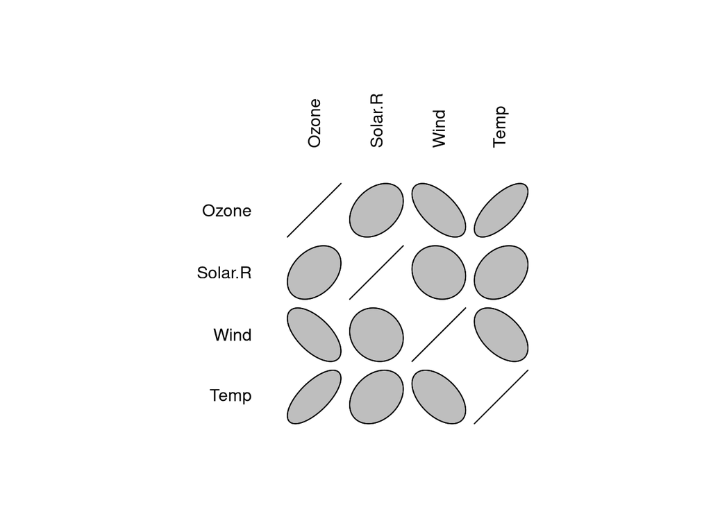

```r
plotcorr(cor(airquality[,1:4], use="complete.obs"))
```

## Between numerical variables and categorical variables

We plot a numerical variable vs a categorical variable

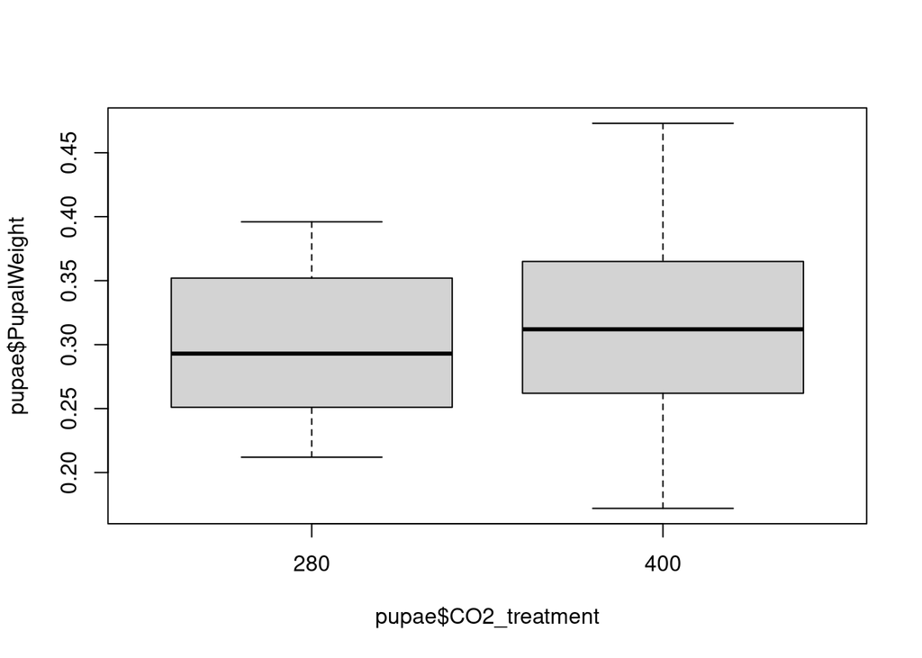

```r
plot(pupae$PupalWeight~pupae$CO2_treatment)
```

a shorter command exploiting the fact the variables belongs to the same dataframe

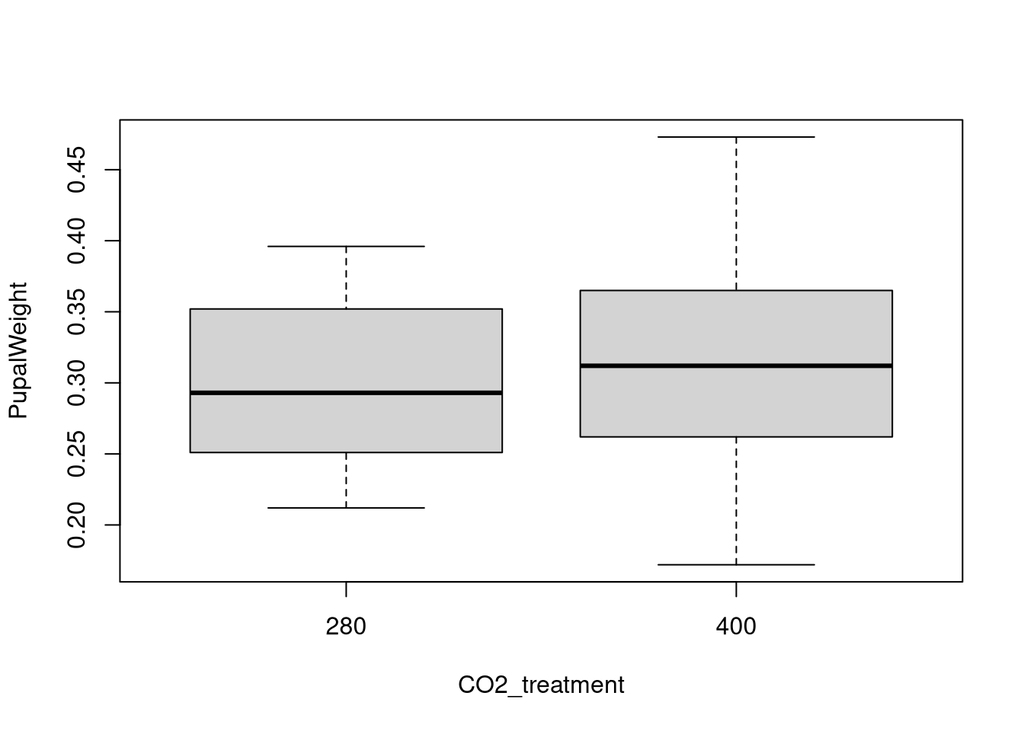

```r
plot(PupalWeight~CO2_treatment,data = pupae)
```

## Between two categorical variables

A contingency table is a type of table in a matrix format that displays the (multivariate) frequency distribution of the variables.

```r
table(pupae$CO2_treatment,pupae$Gender)
```

```
##
##        0  1
##   280 21 16
##   400 22 19
```

The following code considers the relative frequencies

```r
table(pupae$CO2_treatment,pupae$Gender)/nrow(pupae)
```

```
##
##               0         1
##   280 0.2500000 0.1904762
##   400 0.2619048 0.2261905
```

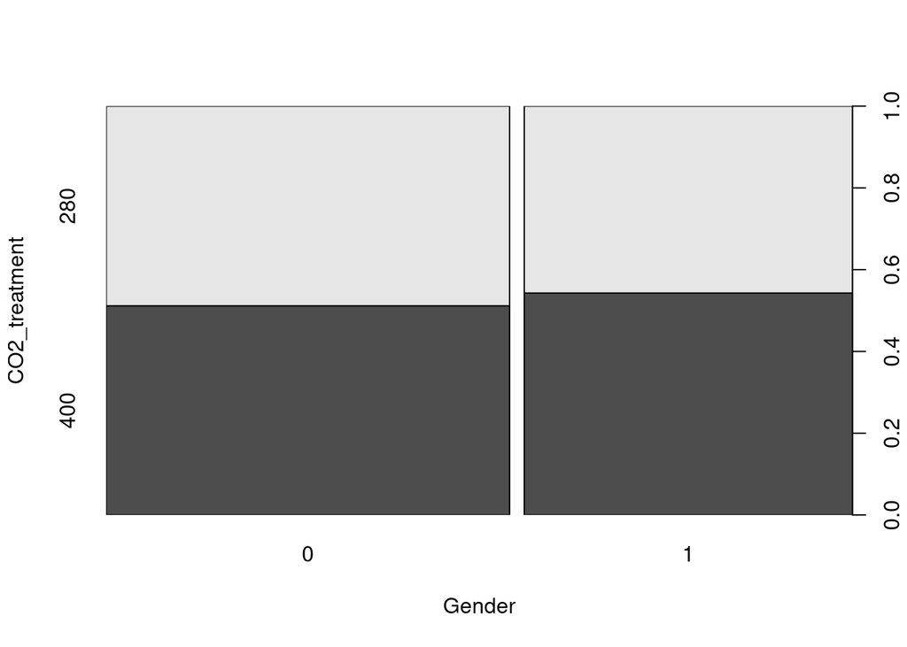

```r
plot(CO2_treatment~Gender,data = pupae)
```

a coloured plot

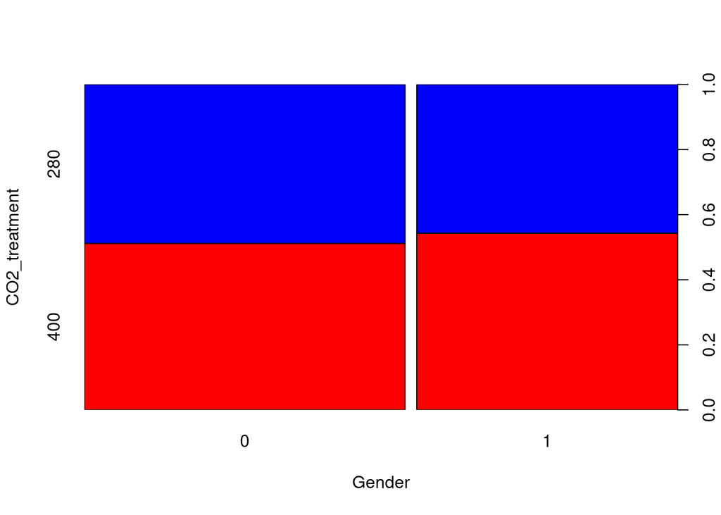

```r
plot(CO2_treatment~Gender,data = pupae,col=c("red","blue"))
```

## Among more than two variables: coplots

In cases involving the relationship between a dependent and independent variable, the relationship may be obscured by the effects of other variables. In such cases it may be useful to examine a scatterplot of x and y, but **conditioned** on a third variable, say z. The `coplot` function does just this, as follows:

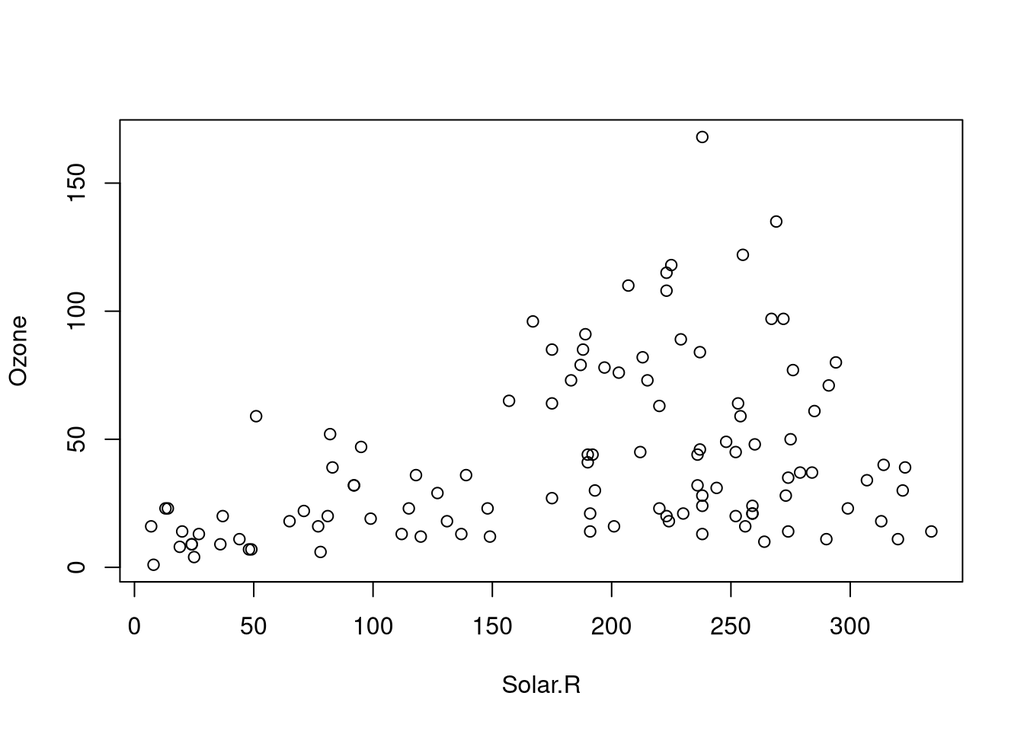

```r
plot(Ozone~Solar.R,data=airquality)
```

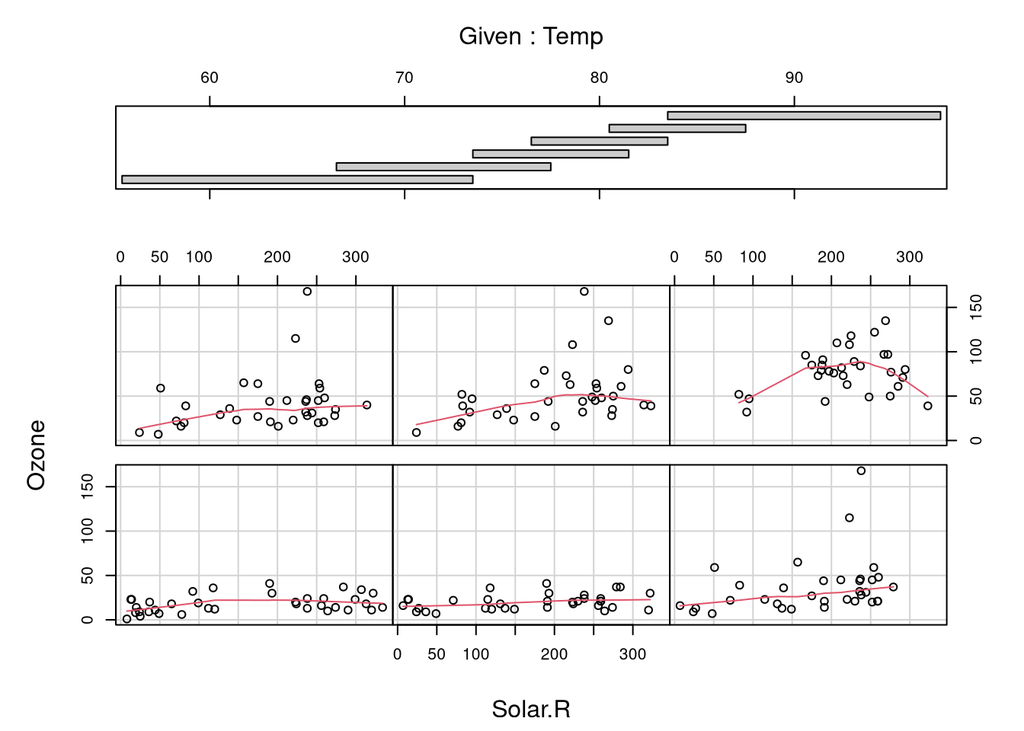

```
##
##  Missing rows: 5, 6, 10, 11, 25, 26, 27, 32, 33, 34, 35, 36, 37, 39, 42, 43, 45, 46, 52, 53, 54, 55, 56, 57, 58, 59, 60, 61, 65, 72, 75, 83, 84, 96, 97, 98, 102, 103, 107, 115, 119, 150
```

```r
coplot(Ozone~Solar.R|Temp,data=airquality,panel=panel.smooth)
```

The bar plot at the top indicates the range of temperature values for each of the plots. The panels are read from bottom left to top right along each row.

Notice that the range of values for temperatures differs between panels and that the ranges overlap from panel to panel. The coplot() function does it’s best to split the data up to ensure there are an adequate number of data points in each panel. If you don’t want to produce plots with overlapping data in the panel you can set the `overlap` argument to `overlap = 0`.